# 3 Buffer Analysis

## 3.1 Overview

Once we have spatially referenced resource locations, it’s helpful to plot the data in the community of interest for some preliminary analysis. In this tutorial we will plot Methadone Providers in Chicago and community areas to provide some context. We will also generate a simple 1-mile **buffer service area** around each provider to highlight neighborhoods with better, and worse, access to resources. In order to accomplish this task, we will need to standardize our spatial data (clinic points, and community areas) with an appropriate coordinate reference system. Finally, we’ll make some maps!

Our objectives are thus to:

- Overlay clinical providers (points) and community areas (polygons)
- Use a spatial transform operation to change coordinate reference systems
- Conduct a simple buffer analysis

## 3.2 Environment Setup

To replicate the code & functions illustrated in this tutorial, you’ll need to have R and RStudio downloaded and installed on your system. This tutorial assumes some familiarity with the R programming language.

### 3.2.1 Input/Output

- Chicago Methadone Clinics, `methadone_clinics.shp`
- Chicago Zip Codes, `chicago_zips.shp`

We will generate a 1-mile buffer around each point, and generate maps with the zip code areas for context. We will also export the final buffer areas as another shapefile for future use.

If you don’t have a shapefile of your data, but already have geographic coordinates as two columns in your CSV file, you can still use this tutorial. A reminder of how to transform your CSV with coordinates into a spatial data frame in R can be found [here](http://geodacenter.github.io/opioid-environment-toolkit/geocodingAddress-tutorial.html#GA-spatial-dataframe).

### 3.2.2 Load Libraries

We will use the following packages in this tutorial:

- `sf`: to manipulate spatial data
- `tmap`: to visualize and create maps

First, load the required libraries.

```r
library(sf)
library(tmap)
```

### 3.2.3 Load Data

Load in the MOUD resources shapefile.

```r
metClinics <- st_read("data/methadone_clinics.shp")
```

Next, we load a shapefile of Chicago zip codes. You can often find shapefiles (or spatial data formats like geojson) on city data portals for direct download. We will walk you through downloading zip code boundaries directly through the Census via R in a later tutorial.

```r
areas <- st_read("data/chicago_zips.shp")
```

Quickly view the first few rows of the zip codes and clinics using your favorite function (`head`, `glimpse`, `str`, and so forth).

```r
head(areas)
```

```
Simple feature collection with 6 features and 4 fields
Geometry type: MULTIPOLYGON
Dimension:     XY
Bounding box:  xmin: -87.80649 ymin: 41.88747 xmax: -87.59852 ymax: 41.93228
Geodetic CRS:  WGS84(DD)
  objectid shape_area shape_len   zip                       geometry
1       33  106052287  42720.04 60647 MULTIPOLYGON (((-87.67762 4...
2       34  127476051  48103.78 60639 MULTIPOLYGON (((-87.72683 4...
3       35   45069038  27288.61 60707 MULTIPOLYGON (((-87.785 41....
4       36   70853834  42527.99 60622 MULTIPOLYGON (((-87.66707 4...
5       37   99039621  47970.14 60651 MULTIPOLYGON (((-87.70656 4...
6       38   23506056  34689.35 60611 MULTIPOLYGON (((-87.61401 4...
```

## 3.3 Simple Overlay Map

We can plot these quickly using the `tmap` library to ensure they are overlaying correctly. If they are, our coordinate systems are working correctly.

We use the tmap “plot” view mode to view the data in a static format.

```r
tmap_mode("plot")
```

```
ℹ tmap mode set to "plot".
```

```
── tmap v3 code detected ───────────────────────────────────────────────────────
[v3->v4] `symbols()`: use 'fill' for the fill color of polygons/symbols
(instead of 'col'), and 'col' for the outlines (instead of 'border.col').
```

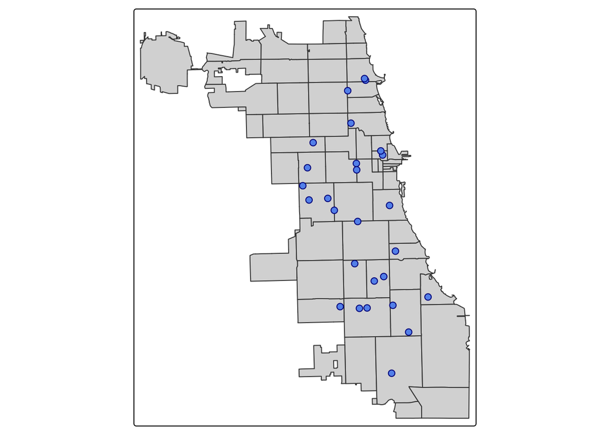

```r
## 1st layer (gets plotted first)
tm_shape(areas) + tm_polygons() +

  ## 2nd layer (overlay)
  tm_shape(metClinics) + tm_symbols(size = 0.5,
                                    border.col= "darkblue", #border color
                                    col="cornflowerblue") #fill color
```

**Funny message about tmap?**

If you got a note that `tmap v3 code` was detected, don’t worry. It happens. Open source packages are always being updated (that’s a feature, not a bug!) and sometimes you’ll need to look up new ways of doing things. In this case we may get a message due to how the points were styles, not an error that prevents us from mapping, so we march on.

## 3.4 Spatial Transformation

Next, we check the Coordinate Reference System for our data. Are the coordinate systems for clinic **points** and community **areas** the same? For R to treat both coordinate reference systems the same, the metadata has to be exact.

```r
st_crs(metClinics)
```

```
Coordinate Reference System:
  User input: WGS 84
  wkt:
GEOGCRS["WGS 84",
    DATUM["World Geodetic System 1984",
        ELLIPSOID["WGS 84",6378137,298.257223563,
            LENGTHUNIT["metre",1]]],
    PRIMEM["Greenwich",0,
        ANGLEUNIT["degree",0.0174532925199433]],
    CS[ellipsoidal,2],
        AXIS["latitude",north,
            ORDER[1],
            ANGLEUNIT["degree",0.0174532925199433]],
        AXIS["longitude",east,
            ORDER[2],
            ANGLEUNIT["degree",0.0174532925199433]],
    ID["EPSG",4326]]
```

```r
st_crs(areas)
```

```
Coordinate Reference System:
  User input: WGS84(DD)
  wkt:
GEOGCRS["WGS84(DD)",
    DATUM["WGS84",
        ELLIPSOID["WGS84",6378137,298.257223563,
            LENGTHUNIT["metre",1,
                ID["EPSG",9001]]]],
    PRIMEM["Greenwich",0,
        ANGLEUNIT["degree",0.0174532925199433]],
    CS[ellipsoidal,2],
        AXIS["longitude",east,
            ORDER[1],
            ANGLEUNIT["degree",0.0174532925199433]],
        AXIS["latitude",north,
            ORDER[2],
            ANGLEUNIT["degree",0.0174532925199433]]]
```

To complicate matters, we are also interested in generating a buffer to approximate a “service area” around each methadone provider. If we want to use a buffer of a mile, we will need to use a spatial data reference system that uses an appropriate distance metric, like feet or meters. As noted in the previous tutorial the WGS84 coordinate reference system uses degrees, and is not an appropriate CRS for the spatial analysis we require.

Thus, our next goal is to transform both spatial data files into a new, standardized CRS.

### 3.4.1 Transform CRS

To calculate buffers, we will need to convert to a different CRS that preserves distance. Trying using a search engine like Google with search terms “CRS Illinois ft”, for example, to look for a code that provides what we need. After searching, we found EPSG:3435 uses feet for a distance metric. We’ll use that!

First, set a new CRS.

```r
CRS.new <- st_crs("EPSG:3435")
```

Next, transform both datasets to your new CRS.

```r
metClinics.3435 <- st_transform(metClinics, CRS.new)
areas.3435 <- st_transform(areas, CRS.new)
```

Check the CRS of both datasets again. If they are identical you’re ready to move onto the next step!

## 3.5 Generate Buffers

Now we are ready to generate buffers! We will create a 1-mile buffer to approximate a service area for an urban area. When choosing an appropriate buffer, consider the conceptual model driving your decision. It’s recommended to review literature on common thresholds, consult patients on how they commonly access services, and consider varying travel modes.

We choose a mile as a walkable distance for urban environments, commonly used for acceptable distance to travel for grocery stores in cities. Because methadone providers may be utilized as often as grocery stores for some patients, it may be a reasonable start for analysis.

We use the `st_buffer` function to create a buffer, and use 5280 feet to equal one mile.

```r
metClinic_buffers <- st_buffer(metClinics.3435, 5280)
```

Inspect the structure of the object you just created. Note that this is a *new* data object, represented as multiple polygons (rather than multiple points). Each buffer around each point is a separate entity.

### 3.5.1 Visualize buffers

Always visualize a spatial object when calculating one, to confirm it worked correctly. If your buffers are much larger or smaller than expected, it’s often a case of mistaken CRS or projection. Retransform your data, and try again.

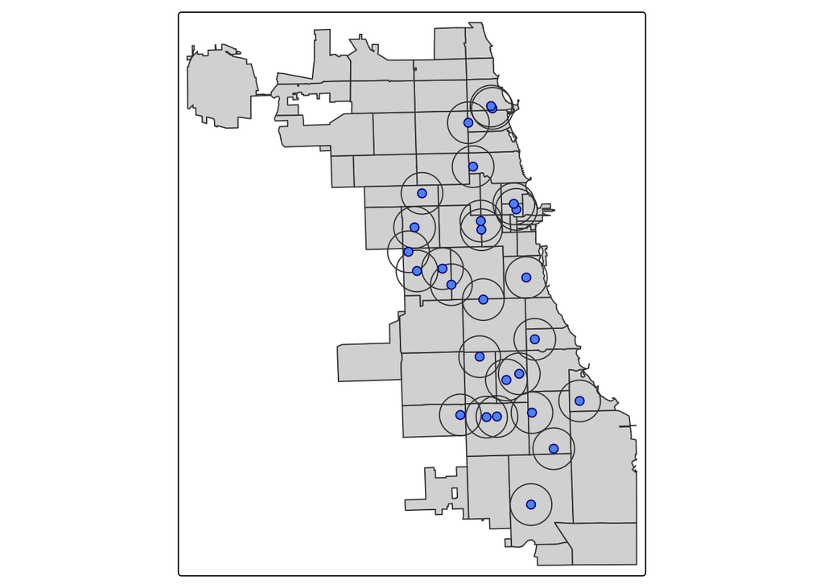

```r
  tm_shape(areas.3435) + tm_polygons() +

  tm_shape(metClinic_buffers) + tm_borders() +

    tm_shape(metClinics.3435) + tm_symbols(size = 0.5,
                                    border.col= "darkblue",
                                    col="cornflowerblue")
```

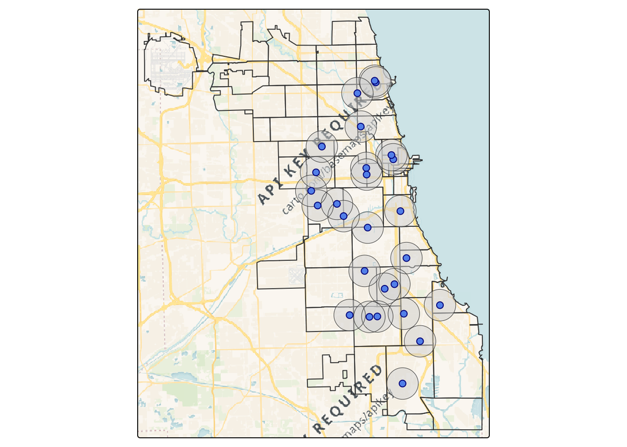

```r
tm_basemap("CartoDB.VoyagerNoLabels") + #Add Basemap

  tm_shape(areas.3435) + tm_borders() + #Include Borders only from Areas

  tm_shape(metClinic_buffers) + tm_borders(alpha = 0.5, #Slightly transparent
                                           lwd = 0.5) + #Reduce line weight

    tm_shape(metClinics.3435) + tm_symbols(size = 0.5,
                                    border.col= "darkblue",
                                    col="cornflowerblue")
```

### 3.5.2 Buffer union

While individual buffers are interesting and can be useful to consider overlapping service areas, we are also interested in getting a sense of which areas fall within a 1-mile service area in our study region – or not. For this, we need to to use a **union** spatial operation. This will flatten all the individual buffers into one entity.

```r
unionBuffers <- st_union(metClinic_buffers)
```

Inspect the data structures of `metClinic_buffers` and `union.buffers` to see what happens to the data in this step.

Finally, we map the buffer union.

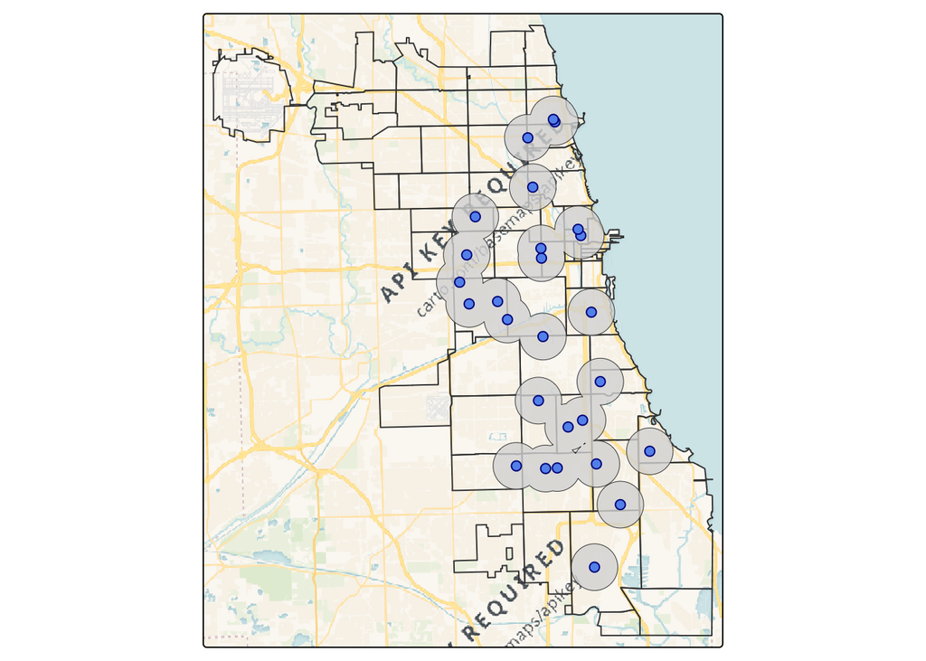

```r
tm_basemap("CartoDB.VoyagerNoLabels") + #Add Basemap

  tm_shape(areas.3435) + tm_borders() + #Include Borders only from Areas

  tm_shape(unionBuffers) + tm_borders(alpha = 0.8, #Less transparent
                                           lwd = 0.5) + #Reduce line weight

    tm_shape(metClinics.3435) + tm_symbols(size = 0.5,
                                    border.col= "darkblue",
                                    col="cornflowerblue")
```

### 3.5.3 Save Data

We will save the merged 1-mile buffers to bring into maps for future analysis. The `st_write` function does the trick. Uncomment, and run on your system!

```r
#st_write(unionBuffers, "data/methadoneClinics_1mi.shp")
```

## 3.6 Rinse & Repeat

From here, we can generate additional buffers to compare access associations and generate multiple visuals.

We generate a two-mile buffer to add:

```r
metClinic_2mbuffers <- st_buffer(metClinics.3435, 10560)
```

### 3.6.1 Explore Cartographic Styles

And then, leverage tmap parameter specifications to further customize the a map showing multiple buffers. We adjust the transparency of the buffer fills, use different colors, and adjust borders to make the visuals pop. Have fun in trying out new combinations!

We use the `tmap_layout` function to take away the frame, add and position a title. Explore the `tmap` documentation further to find additional options for legends and more. To find color options in R, there are multiple guides online (like [this](https://bookdown.org/hneth/ds4psy/D-2-apx-colors-essentials.html) one).

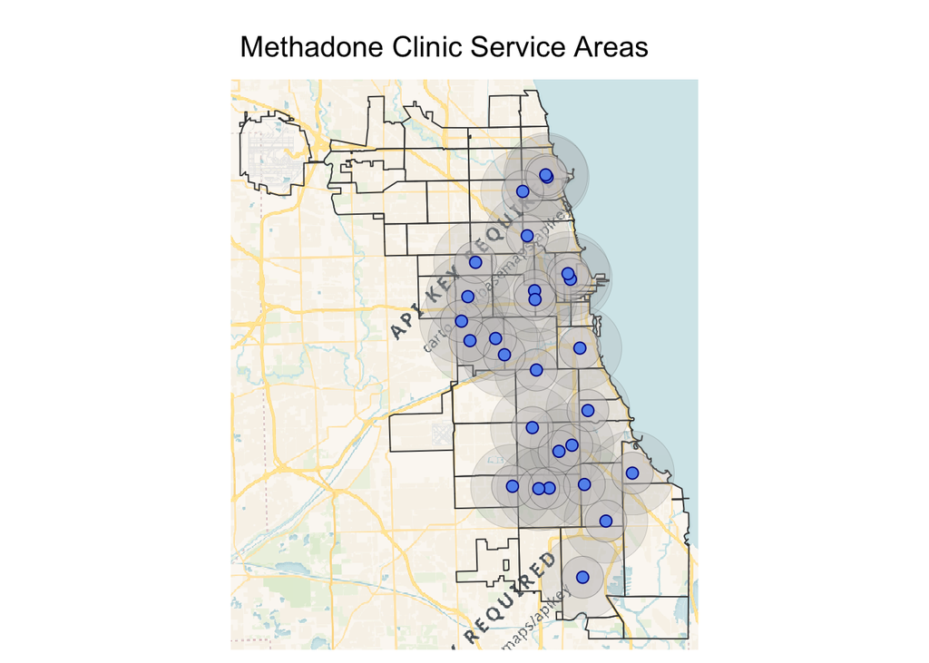

```r
tm_basemap("CartoDB.VoyagerNoLabels") + #Add Basemap

  tm_shape(areas.3435) + tm_borders() +

  tm_shape(metClinic_2mbuffers) + tm_polygons(alpha = 0.2,
                                           fill = "darkgray",
                                           lwd = 0.1) +

  tm_shape(metClinic_buffers) + tm_polygons(alpha = 0.5,
                                            fill = "snow3",
                                           lwd = 0.2) + #Reduce line weight +

    tm_shape(metClinics.3435) + tm_symbols(size = 0.6,
                                    border.col = "darkblue",
                                    col="cornflowerblue") +

  tm_layout(main.title = "Methadone Clinic Service Areas",
            main.title.position = "center",
            frame = FALSE)
```

Next, we’ll try an interactive map to better explore the data that we have. We switch the `tmap_mode` to “view” and focus on our buffer service areas, trying out a new color palette. We add labels for zip codes using the `tm_text` parameter. The resulting map lets us zoom and out to explore the data. Clicking on a point will give additional details about the Methadone provider.

```r
tmap_mode("view")

  tm_shape(metClinic_2mbuffers) + tm_polygons(col = "darkmagenta",
                                              alpha = 0.2, lwd = 0) +

    tm_shape(metClinic_buffers) + tm_polygons(col = "darkorchid4",
                                              alpha = 0.4, lwd = 0) +

    tm_shape(areas.3435) + tm_borders() + tm_text("zip") +

    tm_shape(metClinics.3435) + tm_symbols(size = 0.5, col ="black")
```

[interactive chart not shown]

Which zip codes are within two miles walking distance to providers? Which areas have the best coverage, versus the most challenging? In future workshops, we’ll learn how to take this visualization to the next stage, by operationalizing a new variable per area. That could mean calculating total buffer intersections per area, distance from the zip code’s center to the nearest resource, calculating area covered by buffers, and more.